# `venv` guide for ONS

Brief intro to setting up `venv` on ONS devices.

`venv` is a built in package in python that creates a new version of the python interpreter allowing you to separate out package dependencies across projects.

## Intro

In order to ensure consistent package management virtual environments need to be used.

In python the main way we ensure consistent packages is by also using requirements.txt files, this contains the specific package versions used to run a project / course.

A virtual environment is a comparmentalised python interpreter (python.exe) with it’s own folder and packages installed locally.

Virtual environments can be switched between (activated and deactivated) depending on the project you are working on or task you want to complete.

By using virtual environments teams can ensure they are all using the same versions of packages.

## Create

- *Assumes Python 3.6 or greater*

To create a virtual environment run

```bash
>python -m venv <path to folder>
```

- Note, do not include the <>

For example, if I wanted a virtual environment called “tutorial-env” in my working directory I would write:

```bash
>python -m venv .\tutorial-env
```

By typing `dir` or `ls` you will now have a new folder in the specified directory called `tutorial-env` or your given name.

# Activate

You are not yet using your created environment - you will first need to activate it.

**You will need to activate your environment every time you open anaconda prompt / your chosen command line interface**.

This is done by writing:

## Windows

```bash
><path to folder>\Scripts\activate
```

In our example case:

```bash
>tutorial-env\Scripts\activate
```

This now turns on our virtual environment for use.

You will see something like `(tutorial-env)` in your command line now.

To deactivate (stop using) your virtual environment you just run:

```bash
>deactivate
```

## Unix

```bash
$ source <path to folder>/bin/activate
```

In our example case:

```bash
$ source tutorial-env/bin/activate
```

This now turns on our virtual environment for use.

You will see something like `(tutorial-env)` in your command line now.

To deactivate (stop using) your virtual environment you just run:

```bash
>deactivate
```

# ONS Error

On ONS machines we have an Anaconda distribution of Python. Anaconda has it’s own environment system `conda`. This can cause “errors” when we use `venv` and Anaconda.

A common error is shown below:

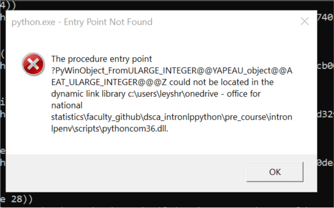

Python Conda Error Message

**This error can be ignored, just press “Ok” when it pops up. It does not break any python code running**. This is just another quirk of our ONS machine configurations.

# Install Packages

You new environment is now completely “clean” it has no packages installed, no `numpy` no `pandas`, only those in the standard library such as `math` or `os`.

To get our packages we need to install them using `pip`.

**You must have your pip configured in order for this to work. For ONS colleagues see the pip section [here](http://np2rvlapxx507/BPI/coding-getting-started-guide/-/wikis/python)**

Reminder: **You will need to activate your environment every time you want to use it**.

## Single package

To install a single package in your environment ensure it is first activated then write:

```bash
>pip install <package name>
```

Such as:

```bash
(tutorial-env)>pip install numpy
```

To find out what packages you have installed run

```bash
(tutorial-env)>pip freeze
```

## Install requirements

You may come across a `requirements.txt` file that contains the package versions you need. All the package versions can be installed at once by using:

```bash
(tutorial-env) >pip install -r requirements.txt
```

In order to generate your own `requirements.txt` file you can save all the packages installed in your current environment to a text file using:

```bash
(tutorial-env)>pip freeze > requirements.txt
```

Note: you may need to use `|` instead of `>` in some instances of Anaconda Prompt.

This `requirements.txt` can now be used by others to get the same version of packages you have been using to work on their machine.

**It is recommended to use a venv to create a requirements.txt from, this avoids unwanted packages being installed by others.**

# Jupyter Notebooks

Jupyter notebooks and other ipy related products need additional steps to get them working with your environment.

To use your environment with jupyter you need to install `ipykernel` and also make jupyter aware of this new kernel. The “kernel” is what runs your python code in the notebook.

First install `ipykernel` **within your virtual environment** - make sure it is activated!

```bash
(tutorial-env)>pip install ipykernel
```

You now need to tell jupyter that it has a new kernel:

```bash
>ipython kernel install --user --name=<venv name>
```

In our case:

```bash
>ipython kernel install --user --name=tutorial-env
```

To now run your jupyter notebook code using your new environment:

- Open your jupyter notebook
- Click `Kernel`
- Click `Change kernel`
- Select your new kernel / virtual environment

If you have run jupyter notebook while your environment was activated it may have selected the correct kernel already.

# Quick Set Up

## Install packages to new environment

```bash
>python -m venv <venv name>

><venv name>\Scripts\activate

>pip install -r requirements.txt
```

## Make jupyter aware of a kernel

If you don’t have `ipykernel` installed already:

```bash
>pip install ipykernel
```

Install kernel to jupyter.

```bash
>ipython kernel install --user --name=<venv name>
```